# Species richness maps and range size estimation from point occurrences

## Background

Patterns of species richness and occurrence density are relevant information for study design, to communicate study results or to check data quality in any multi-species occurrence dataset. Species distributions can be estimated with a large array of methods, but in some cases a rough and quick estimation of species ranges is more suitable. The extent of occurrence based on convex hulls is used in conservation and macroecology to approximate species’ ranges.

## Objectives

After this exercise you will be able to: 1. Visualize species richness patterns and occurrence record density in a quick and efficient way. 2. Estimate species distribution ranges based, and create polygons of species distributions.

## Exercise

1. Load the example data, and visualize the coordinates on a map.
2. Visualize the number of occurrence records and the number of species in a regular-sized grid (`RichnessGrid`).
3. Estimate the range for each species using a convex hull. Write the range maps to the working directory as ESRI-shape files (`writeOGR`, `plot`, `CalcRange`).
4. Visualize species richness per grid cell based on the range polygons (`RangeRichness`).
5. Visulaize species richenss in an equal area raster (`raster`, `spTransform`, `coordinates`).
6. Write the result rasters to a file on your disk

## Possible questions for your project

- Where is the diversity centre of the group?
- Where are centres of record collection?

## Library setup

You will need the following R libraries for this exercise, just copy the code chunk into you R console to load them. You might need to install some of them separately.

```r
library(tidyverse)
library(speciesgeocodeR)
library(raster)
library(rgdal)
```

## 1. Load occurrence data and visualize

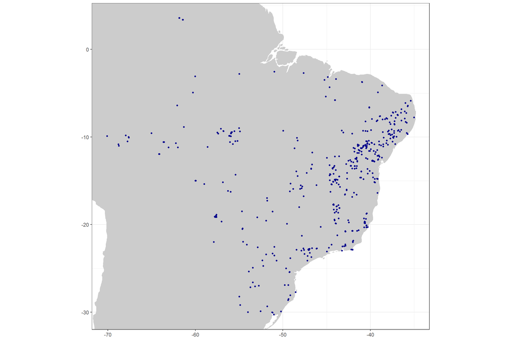

```r
dat <- read_csv("inst/occurrence_records_clean.csv")

# Visualize

world.inp <- map_data("world")

ggplot() + geom_map(data = world.inp, map = world.inp, aes(x = long, y = lat,
    map_id = region), fill = "grey80") + xlim(min(dat$decimalLongitude, na.rm = T),
    max(dat$decimalLongitude, na.rm = T)) + ylim(min(dat$decimalLatitude, na.rm = T),
    max(dat$decimalLatitude, na.rm = T)) + geom_point(data = dat, aes(x = decimalLongitude,
    y = decimalLatitude), colour = "darkblue", size = 1) + coord_fixed() + theme_bw() +
    theme(axis.title = element_blank())
```

## 2. Visualize the number of occurrence records and the number of species in a regular-sized grid (`RichnessGrid`)

For a quick overview you can first visualize pattern in a lat/long grid.

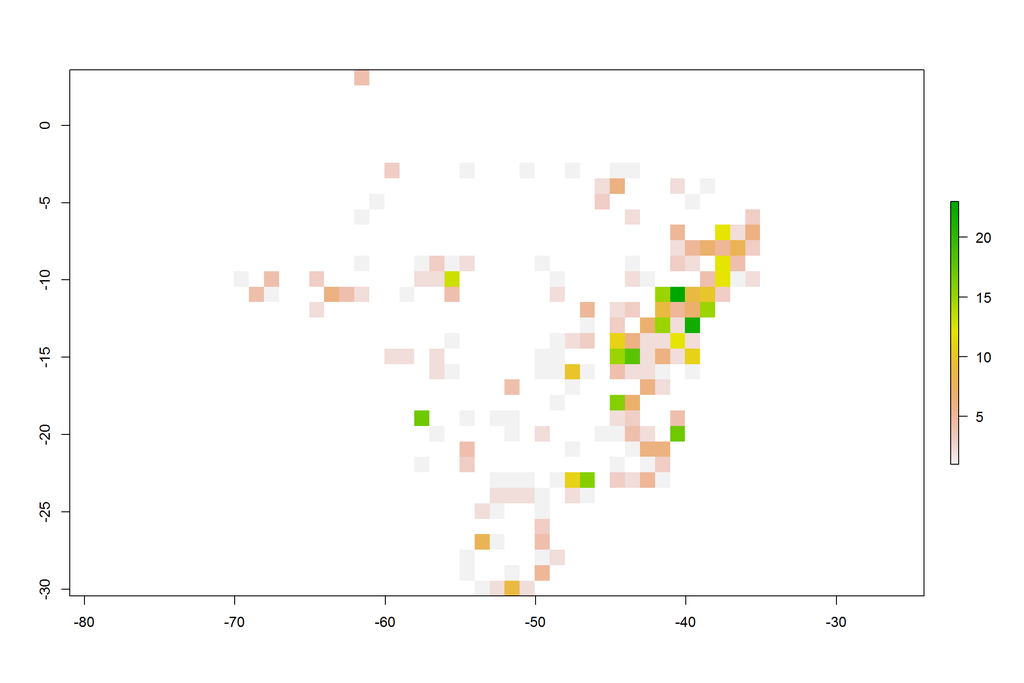

```r
# The number of occurrences per grid cell
gocc <- RichnessGrid(dat, type = "abu")
plot(gocc)
```

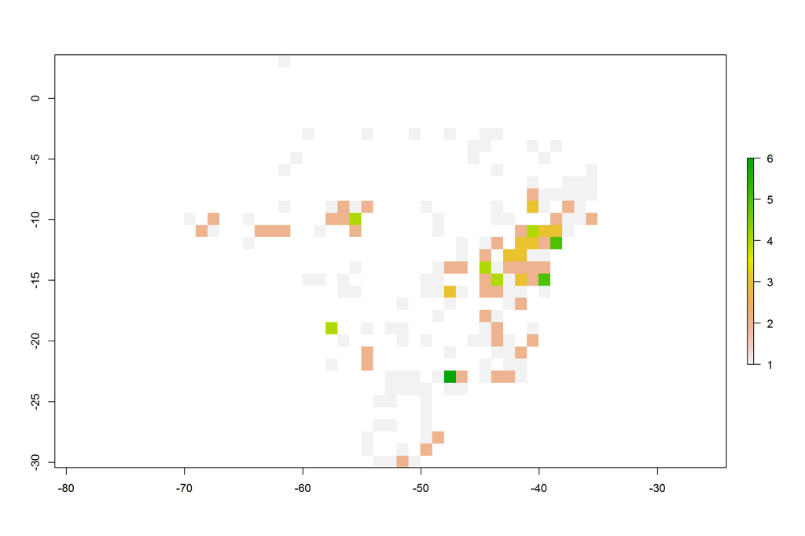

```r
# The number of species per grid cell
gri <- RichnessGrid(dat)

plot(gri)
```

# 3. Convex hull ranges per species

As the simplest model of species distribution we can use convex hull to fill the gaps.

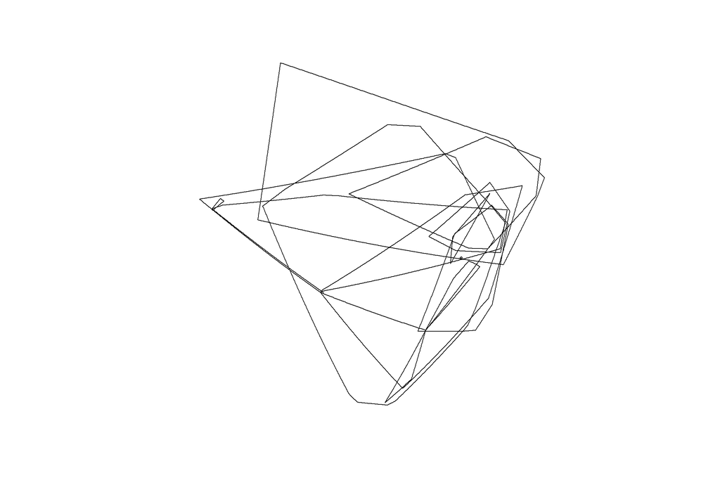

```r
# Calculate ranges
ranges <- CalcRange(dat)

# Visualize
plot(ranges)
```

```r
# Write to working directory
writeOGR(ranges, dsn = "inst", layer = "range_polygons", driver = "ESRI Shapefile")
```

## 4. Visualize species richness per grid cell based on the range polygons.

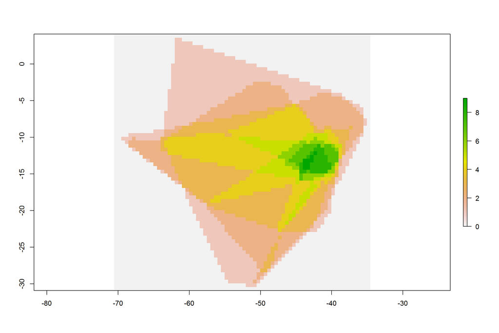

```r
# Create richness raster
r_ri <- RangeRichness(ranges, res = 0.5)

plot(r_ri)
```

## 5. Visualise species richenss in an equal area raster

So far we have displayed species richness in a lat/lon projected raster. This is OK to get a feeling for the data, but strictly speeaking wrong, since the actuala rea of a 1x1 degree cell varies with latitude. So, it is better to use an eaqual area pojection, such as the Lamberts projection.

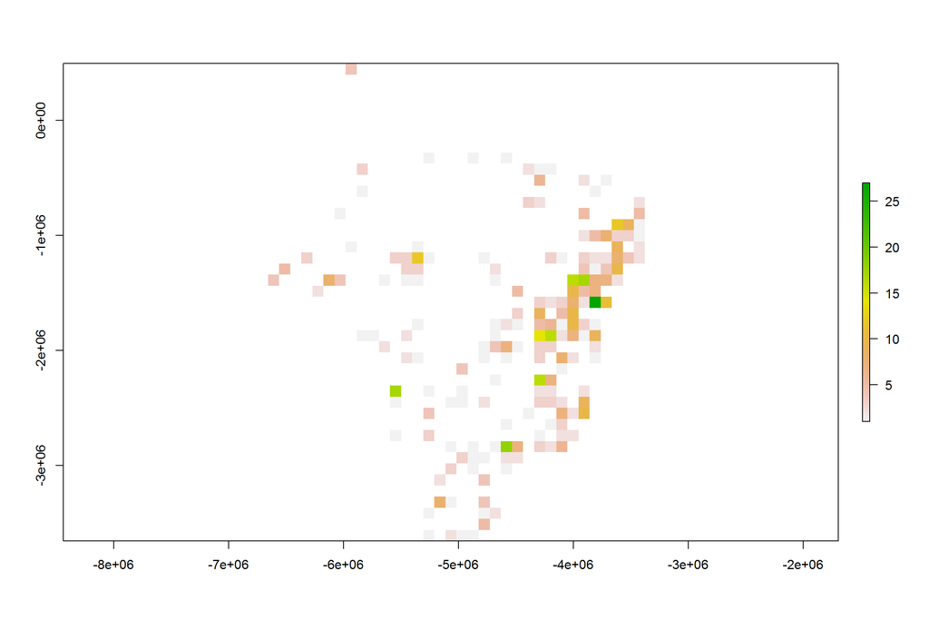

```r
# Define projections
wgs1984 <- CRS("+proj=longlat +ellps=WGS84 +datum=WGS84 +no_defs")
behr <- CRS("+proj=cea +lon_0=0 +lat_ts=30 +x_0=0 +y_0=0 +datum=WGS84 +ellps=WGS84 +units=m +no_defs")

# reproject the occurrence records
pts <- dat[, c("decimalLongitude", "decimalLatitude")] %>% SpatialPoints(proj4string = wgs1984) %>%
    spTransform(behr)

# create a aqual area template in behrman projection
be <- raster(ncol = 360, nrow = 142, xmn = -17367529, xmx = 17367529, ymn = -6356742,
    ymx = 7348382, crs = behr)
be <- crop(be, extent(pts))

pts <- data.frame(dat$species, coordinates(pts))

# Equal area Occurrence number
eq_occgri <- RichnessGrid(x = pts, ras = be, type = "abu")
plot(eq_occgri)
```

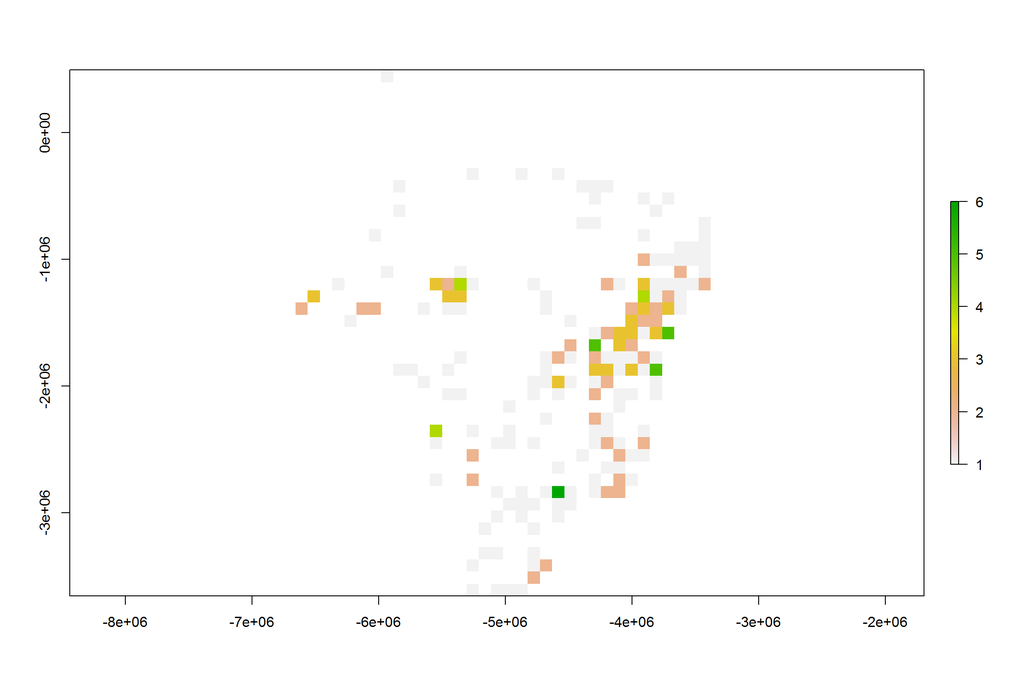

```r
# Equal area speces richness
eq_rigri <- RichnessGrid(x = pts, ras = be)
plot(eq_rigri)
```

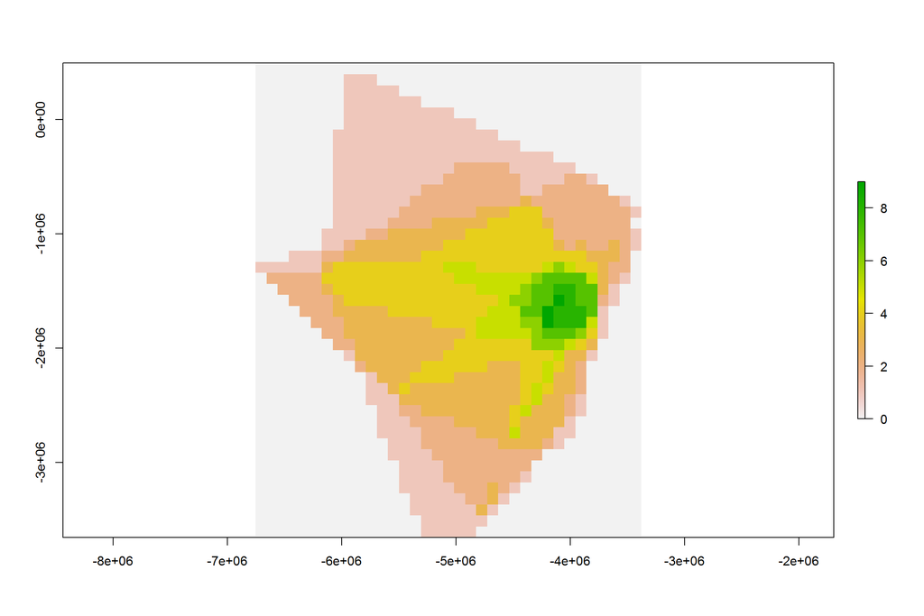

```r
# Range based species richness
ranges <- spTransform(ranges, behr)

eq_rri <- RangeRichness(x = ranges, ras = be)

plot(eq_rri)
```

6. Write to disk

```r
writeRaster(eq_rri, filename = "inst/equal_area_range_richness", format = "ascii",
    overwrite = TRUE)
```